# Procesos de conformación de metales

## Introducción

La **conformación** es el conjunto de procesos mediante los cuales se da **forma a los materiales metálicos** sin alterar de manera importante su composición química. Estos procesos buscan obtener piezas útiles para la industria con determinadas **formas, dimensiones y propiedades mecánicas**. Entre éstos están el moldeo, el forjado, el estrujado y el trafilado.

## Moldeo

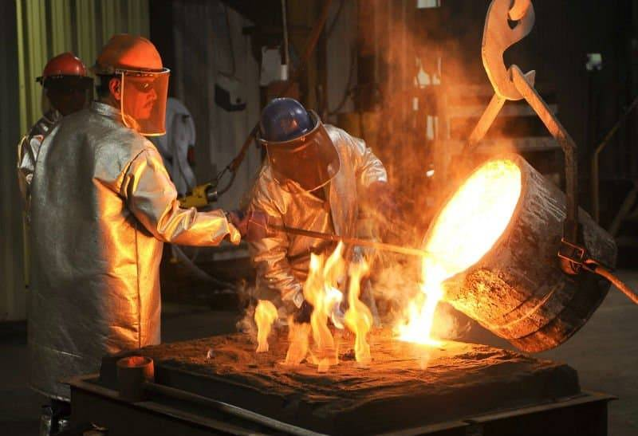

Moldeo de piezas. Fuente: metalmecanica.com

- **Definición:** Consiste en **fundir el metal** y verterlo en un molde donde solidifica con la forma deseada.
- **Ejemplos:** piezas de motores, campanas, carcasas.
- **Ventajas:** permite fabricar formas complejas.
- **Limitaciones:** posible presencia de defectos (porosidades), menor resistencia mecánica que otros procesos.

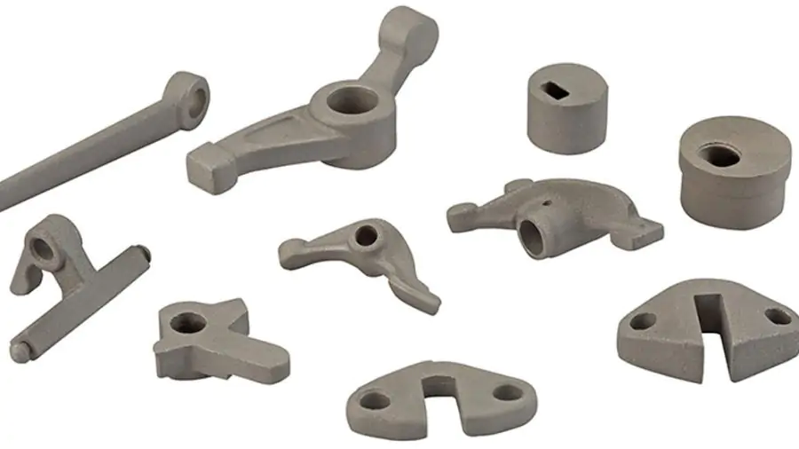

Piezas moldeadas. Fuente: omeroglumetalurji.com

## Forjado

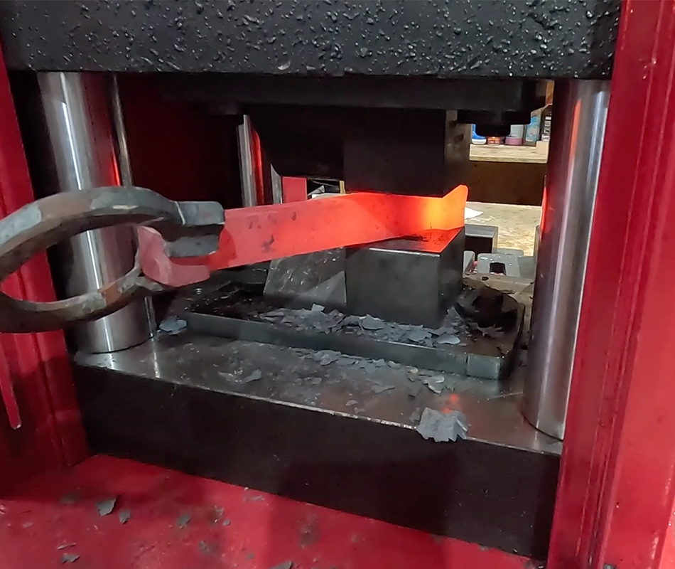

Prensa hidráulica forjando en caliente. Fuente: nargesa.com

- **Definición:** Proceso de conformación en el que el metal en **estado sólido** se deforma mediante **golpes o presión**.
- **Formas de trabajo:**
  - **En frío:** mayor dureza y precisión, pero más esfuerzo.
  - **En caliente:** el metal se calienta y se deforma más fácilmente, mejorando la estructura interna.
- **Tipos:**
  - **Libre:** golpes sobre yunque o prensa, sin molde definido.
  - **En matriz:** el metal se comprime entre moldes que le dan forma exacta.
- **Ejemplos:** bielas, ejes, cigüeñales, llaves.
- **Ventajas:** gran resistencia y tenacidad por la compactación de los granos.
- **Limitaciones:** requiere energía, equipos potentes y suele necesitar mecanizado posterior.

(Texto en inglés)

- **Definition:** A forming process in which the metal in **solid state** is deformed by **hammering or pressure**.
- **Working methods:**
  - **Cold forging:** greater hardness and precision, but requires more effort.
  - **Hot forging:** the metal is heated and deforms more easily, improving its internal structure.
- **Types:**
  - **Open die:** hammered or pressed on an anvil or press, without a defined mold.
  - **Closed die (die forging):** the metal is compressed between molds that give it an exact shape.
- **Examples:** connecting rods, shafts, crankshafts, wrenches.
- **Advantages:** high strength and toughness due to grain compaction.
- **Limitations:** requires energy, heavy equipment, and usually needs further machining.

## Extrusión

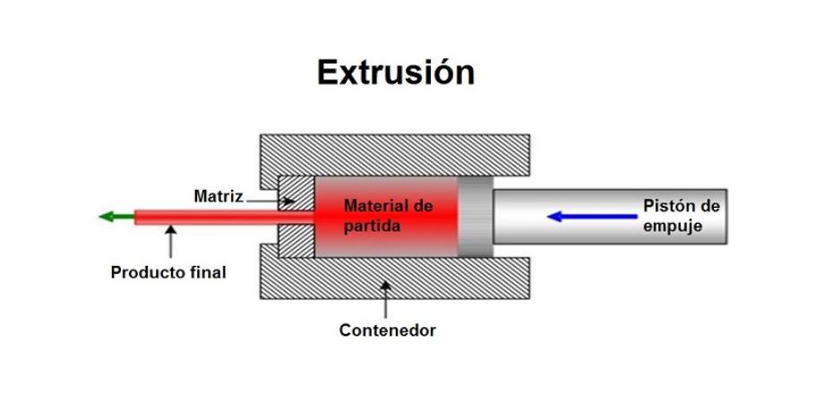

Fuente: portalum.com

- **Definición:** Se hace pasar el metal (blando o caliente) a través de una **matriz** para que adopte su forma.
- [Mirá este momento puntual del video](https://www.youtubetrimmer.com/view/?v=YcGcMBnQ0I4&start=29&end=86&loop=0) en donde se muestra como un redondo de aluminio se calienta, se corta y se extruye formando un perfil.
- **Comparación:** parecido a cuando apretamos plastilina por un molde.
- **Ejemplos:** tubos, perfiles de aluminio, barras de cobre.
- **Ventajas:** formas continuas y regulares.
- **Limitaciones:** más útil en metales dúctiles.

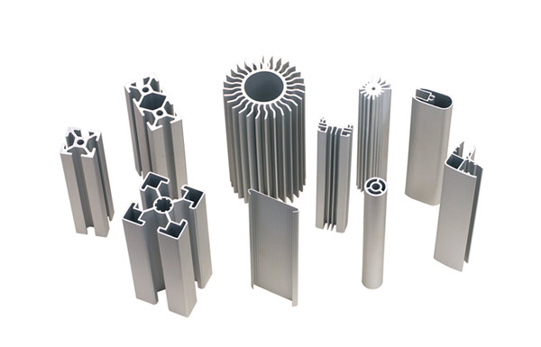

Piezas extruidas. Fuente: leadrp.net

## Trefilado

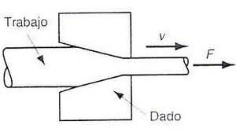

Trefilado de alambre. Fuente: wiki.ead.pucv.cl

- **Definición:** Proceso en el que un alambre o barra se **estira pasando por orificios cada vez más pequeños** hasta lograr el diámetro deseado.
- **Ejemplos:** alambres eléctricos, cables de acero, agujas.
- **Ventajas:** gran precisión dimensional y buena resistencia.
- **Limitaciones:** limitado a secciones relativamente pequeñas.

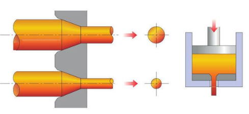

Diferencia entre trefilar (tirar) y extruir (empujar). Fuente: ud-machine.com